# Scotland Mortality Projections

Jon Minton

# Introduction

This document will present life expectancy and age specific mortality observed in Scotland since 2012 in comparison with projections based on earlier trends.

Two periods will be considered when informing the pre-2012 trends:

- 1950-2011
- 1990-2011

## Background literature: why ARIMA(0,1,0) is OK

[Lee (2002)](https://link.springer.com/chapter/10.1007%2F978-3-030-05075-7_14), who co-created the [Lee-Carter model](https://www.jstor.org/stable/2290201?seq=1#page_scan_tab_contents) for mortality projection in the early 1990s, accepted in the mid/late 2000s, as a result of analyses by [White (2002)](https://onlinelibrary.wiley.com/doi/abs/10.1111/j.1728-4457.2002.00059.x) and [Oeppen & Vaupel (2002)](http://truemedmd.com/wp-content/uploads/2013/07/Life_expectancy_scienceMay2002.pdf), that a much simpler modelling approach is often adequate for life expectancy forecasting. This approach involves modelling life expectancy at birth ($e_0$) directly, rather than individual age specific mortality rates ($m_{x}$) and quantities derived from them (a ‘drift parameter’ $k$) as in Lee-Carter’s original model specification.

Although [Lee (2002)](https://link.springer.com/chapter/10.1007%2F978-3-030-05075-7_14) presents a number of refinements of a basic linear life expectancy forecase model specification, including models which allow for negative autocorrelation between change in years, the article states that the basic strategy for forecasting should be “to use the appropriate or preferred equation for $de_{t}/dt$ [change in life expectancy] to estimate $e0$ one year later, and then continue recursively.” This is the approach this projection exercise will follow

## Modelling strategy

We have $e_0 (s, t)$, the life expectancy at birth for sex $s$ and time $t$, extracted from the Human Mortality Database (HMD) from 1855 to 2016, and from the ONS for 2017 and 2018 (by males and females only, not total population). We define $\Delta e_0 (s, t)$ as change in life expectancy for sex $s$ from year $t$ to year $t + 1$.

We first plot both $e_0$ against $t$ by $s$, and $\Delta e_0$ against $t$ by $s$, to identify appropriate pre-slowdown time periods, i.e. the range of years prior to 2012 (our assumed breakpoint in mortality trends) to use to calibrate projections of life expectancy trends from 2012 to 2018 onwards. Based on these plots and background knowledge, we selected two pre-slowdown periods:

- $P_1$: 1950-2011 inclusive
- $P_2$: 1990-2011 inclusive

For both of these pre-slowdown periods, we calculated the mean annual change observed by sex (i.e. $E(\Delta e_0 (t \in P, s))$) and the variance in mean annual changes over the same period (i.e. $Var(\Delta e_0 (t \in P, s)$).

To project forward estimates of life expectancy trends based on pre-slowdown observations in a way that takes into account observed variation in annual changes, we sample and accumulate $k$ draws from Normal distributions calibrated on the sample means and variances from the pre-slowdown period ($P_1$ or $P_2$), where $k$ refers to the number of annual periods we want to project forward from 2011. As we want to project forward to 2018 we therefore select $k = 7$. This exercise is repeated $m = 10,000$ times to allow credible intervals in forecasts to be calculated using a Monte-Carlo approach. Life expectancy projections for each year 2012-2018 inclusive are produced by summing up the draws from the first projected period onwards; the life expectancy from 2011 (the last observation in the pre-slowdown period) is added to these summed values to produce predicted life expectancies rather than cumulative gains or losses in life expectancy since 2011. Algebraically this can be expressed as follows:

$$e_{0}^{*} (t = \tau + K) = e_{0}(t=\tau) + \sum_{k=1}^{K} N_{k}$$
$$N \sim Normal(\mu = E(\Delta e_0(P), \sigma^{2} = Var(\Delta e_0({P}))))$$

Where $\tau$ refers to 2011, $K$ the discrete number of periods to forecast after $\tau$, and $\Delta e_{0} (P)$ the series of annual changes over the pre-slowdown period $P$.

Load packages required

```r
pacman::p_load(HMDHFDplus, tidyverse, broom)
```

# Data

The data used are described below. The code will not be run/evaluated as the data have already been downloaded.

```r
# Single year life tables for Scotland available here:

# https://www.ons.gov.uk/peoplepopulationandcommunity/birthsdeathsandmarriages/lifeexpectancies/datasets/singleyearlifetablesuk1980to2018

# Downloaded to data folder (see singleyearlifetablesscland.xls)

# load e0 for scotland
# dta_scot <- HMDHFDplus::readHMDweb("GBR_SCO", item = "E0per", username = userInput(), password = userInput())
# dta_scot

# load mx for scotland
# dta_scot_mx <- HMDHFDplus::readHMDweb("GBR_SCO", item = "Mx_1x1", username = userInput(), password = userInput())
# HMDHFDplus::getHMDitemavail("GBR_SCO", username = userInput(), password = userInput())

# bring to tidy format
# dta_scot_tidy <-
#   dta_scot %>%
#     as_tibble() %>%
#     rename_all(tolower) %>%
#     gather(-year, key = "sex", value = "e0")

# write e0 to directory
# write_csv(dta_scot_tidy, "data/e0_scot.csv")
```

The data will now be loaded locally, and augmented with the last couple of years’ e0

```r
dta_scot_tidy <- read_csv("data/e0_scot.csv")
# manually adding last two years from table listed above
dta_scot_tidy <-
  dta_scot_tidy %>%
    bind_rows(
      tribble(
        ~year, ~sex, ~e0,
        2017, "male", 77.13,
        2017, "female", 81.16,
        2018, "male", 77.05,
        2018, "female", 81.01
      )
    )
# n.b. does not include total
```

# Visualise e0 at birth

The following chunk shows life expectancy at birth over all available years

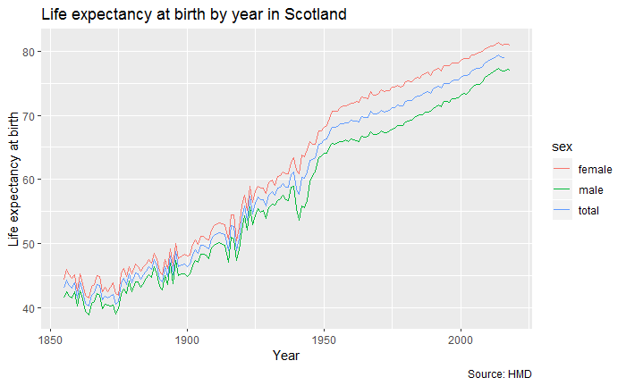

```r
dta_scot_tidy %>%
  ggplot(aes(x = year, y = e0, group = sex, colour = sex)) +
  geom_line() +
  labs(
    x = "Year",
    y = "Life expectancy at birth",
    title = "Life expectancy at birth by year in Scotland",
    caption = "Source: HMD"
  )
ggsave("figures/scot_e0.png", height = 15, width = 25, dpi = 300, units = "cm")
```

Another, less familiar, way of visualising this data is in annual changes in e0. This will be more useful for informing our model

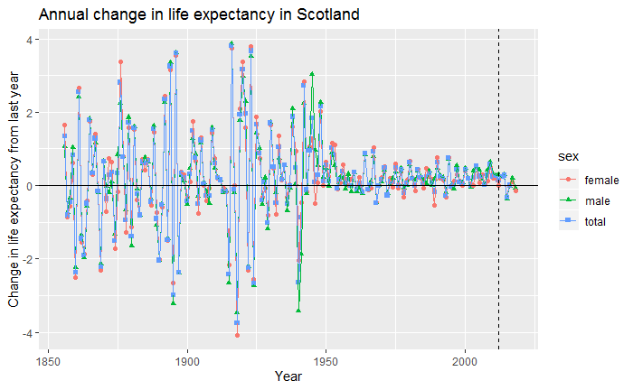

```r
dta_scot_tidy %>%
  group_by(sex) %>%
  arrange(year) %>%
  mutate(delta_e0 = e0 - lag(e0)) %>%
  ungroup () %>%
  ggplot(aes(x = year, y = delta_e0, group = sex, colour = sex, shape = sex)) +
  geom_point() + geom_line() +
  labs(
    x = "Year", y = "Change in life expectancy from last year",
    title = "Annual change in life expectancy in Scotland"
  ) +
  geom_hline(yintercept = 0) +
  geom_vline(xintercept = 2012, linetype = "dashed")
ggsave("figures/scot_e0_annual_change.png", height = 15, width= 25, dpi = 300, units = "cm")
```

The reason for not using data from before 1950 is clear from this. Before 1950 there was much more variation in life expectancy than there has been since.

Let’s look at the trend and life expectancy from 1950 onwards

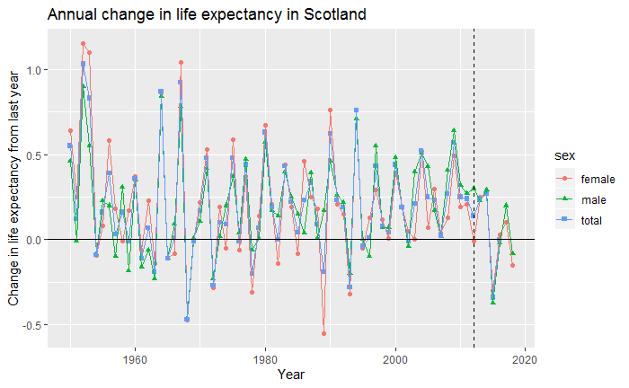

```r
dta_scot_tidy %>%
  group_by(sex) %>%
  arrange(year) %>%
  mutate(delta_e0 = e0 - lag(e0)) %>%
  ungroup() %>%
  filter(year >= 1950) %>%
  ggplot(aes(x = year, y = delta_e0, group = sex, colour = sex, shape = sex)) +
  geom_point() + geom_line() +
  labs(
    x = "Year", y = "Change in life expectancy from last year",
    title = "Annual change in life expectancy in Scotland"
  ) +
  geom_hline(yintercept = 0) +
  geom_vline(xintercept = 2012, linetype = "dashed")
ggsave("figures/scot_e0_annual_change_since_1950.png", height = 15, width = 25, dpi = 300, units = "cm")
```

We can see there are similar, but not identical, patterns observed for both sexes. Previous research has demonstrated one year negative autocorrelation in the series, i.e. that ‘good’ years tend to precede ‘bad’ years and vice versa. [White (2002)](https://onlinelibrary.wiley.com/doi/abs/10.1111/j.1728-4457.2002.00059.x) noted that, for changes in life expectancy in high income countries as a whole, there was a “small but significant negative relationship between change in average life expectancy in one year and change in the next”, and that:

> The negative relationship between change in $e_0$ from one year to the next may represent a tendency for misestimates or random shocks to life expectancy to be corrected in the subsequent year. For example, a particularly virulant flu epidemic might cause a low rise in life expectancy that year. But if deaths are raised or overestimated in one year, a return to normal levels in the next would tend to cause a low rise in life expectancy to be followed by a high one.